# TikTok Advertising Video Story

## What is this data about?

This visual data story is about TikTok advertisement videos. I used a Google Form to record the advertisements I saw when I was using TikTok. Each row in my data is one advertisement, so the data is based on my and my teammate observation.

I recorded three main things: the advertisement type, the advertisement time in seconds, and how likely I would click on the advertisement. I wanted to know what kind of advertisements TikTok showed me more often, and whether the advertisements had similar or different lengths.

When I first looked at the data, I expected that the most common advertisement type might also be the longest type. However, the visualisations show a more interesting pattern.

## Food and Drink appeared the most often

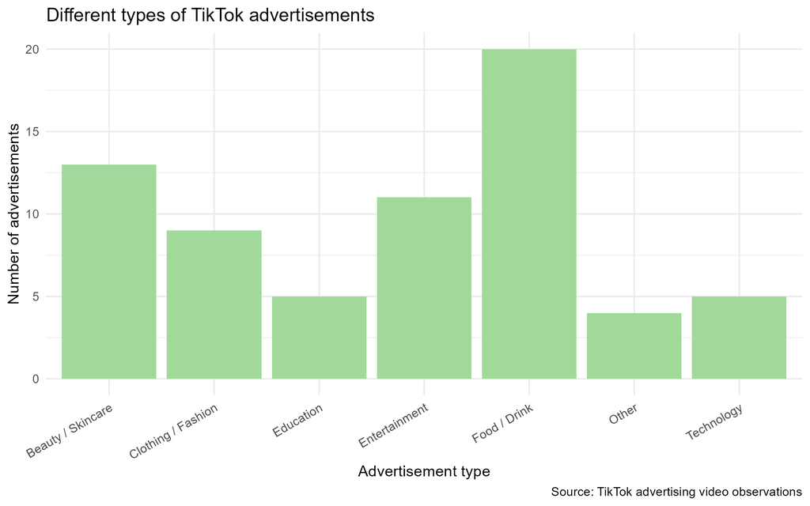

A bar chart showing the number of TikTok advertisements for each advertisement type. Food and Drink has the highest number of advertisements.

In the first chart, the number of different advertisement types is not evenly distributed. In my data, Food and Drink advertisements appeared the most often. Beauty and Skincare, Entertainment, and Clothing or Fashion advertisements also appeared, but they appeared less often than Food and Drink advertisements.

The category with the fewest advertisements was Other. Compared with Food and Drink, this category was recorded much less often. This shows that although I saw many different types of advertisements, Food and Drink was the type I saw most often on TikTok.

This is the first part of my story. TikTok did not show all advertisement types equally to me. Some advertisement types were recommended more often, especially Food and Drink advertisements.

## The most common type was not the longest type

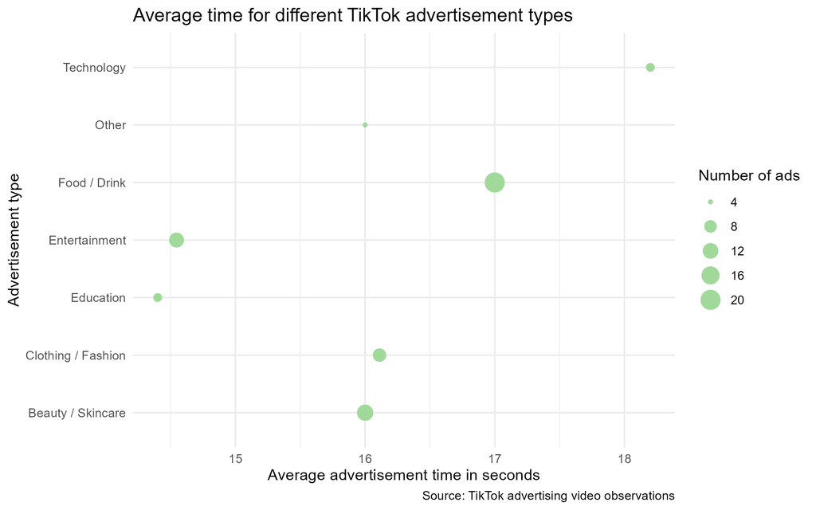

A point plot showing the average advertisement time for different TikTok advertisement types. The size of each point shows the number of advertisements.

The second plot compares the average advertisement time for each type. The x-axis shows the average time in seconds, and the y-axis shows the advertisement type. The size of the point shows how many advertisements were in that type. A bigger point means that type appeared more often.

Food and Drink has the biggest point because it had the most advertisements. However, it was not the longest type on average. Technology had a longer average advertisement time, but it had fewer advertisements, so the point is smaller.

This is an important part of the story. The type that appeared the most often was not the type with the longest average time. This means frequency and duration are not the same thing. A type can appear often, but it does not have to be the longest.

## Advertisement length changed between observations

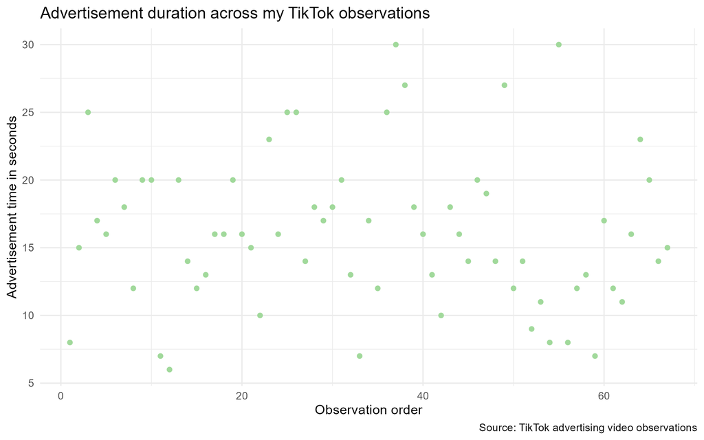

A scatter plot showing advertisement duration across the observation order. Each point represents one TikTok advertisement.

The third plot uses the timestamp from Google Form to put my observations in time order. I used observation order instead of date because most of my observations were collected on the same day and in a short time. If I used date, the plot would only show one main date group, so it would not tell a useful story.

In this plot, each point is one advertisement. The x-axis shows the observation order, and the y-axis shows the advertisement time in seconds. The points are quite spread out, which means the advertisement times were not all similar.

There is no very clear increasing or decreasing trend. This means I cannot say the advertisements became longer or shorter over time. Instead, the plot shows that the duration changed from one advertisement to another. Most advertisements were around a short to medium length, but a few advertisements were much longer, such as close to 30 seconds.

This gives the final part of the story: even in a short observation time, the advertisements had different lengths.

## What does this story show?

Overall, my visual data story shows that TikTok advertisements in my observations were not all the same. Food and Drink advertisements appeared the most often, but they were not the longest type on average. Technology advertisements had a longer average time, even though they appeared less often.

The individual advertisement times were also different. The scatter plot does not show a clear upward or downward trend, but it shows that the points are spread out. This means the advertisement duration changed between different observations.

Together, the three plots show a simple story. First, TikTok showed me more Food and Drink advertisements. Second, the most common type was not always the longest type. Third, individual advertisements had different durations, and there was no clear time trend in my short observation period.